# Growth rate comparisons

The purpose of this document is to 1) test for differences between NH and GA/NC Urosalpinx population growth rates at all common garden temperatures and 2) test for significant differences in initial hatchling size between populations.

## Growth Rate Comparison, common garden experiment

### New Hampshire-Georgia

From our two-way ANOVA, we see that variance in growth rate is significantly different between populations across all temperatures.

Using post-hoc t-tests between Georgia and New Hampshire populations, we see that 16 and 24 degrees there is no significant difference in growth rate. At 20 C and the three highest temperatures, we see that growth rate is significantly larger.

```
##             Df Sum Sq Mean Sq F value   Pr(>F)
## pop          1   4.35    4.35   7.311  0.00964 **
## temp         1  48.35   48.35  81.328 1.19e-11 ***
## pop:temp     1   5.38    5.38   9.049  0.00429 **
## Residuals   45  26.75    0.59
## ---
## Signif. codes:  0 '***' 0.001 '**' 0.01 '*' 0.05 '.' 0.1 ' ' 1
```

```
##   temp     p-value
## 1   16 0.135430985
## 2   20 0.017559232
## 3   24 0.072206856
## 4   26 0.034056323
## 5   28 0.009529978
## 6   30 0.003973116
```

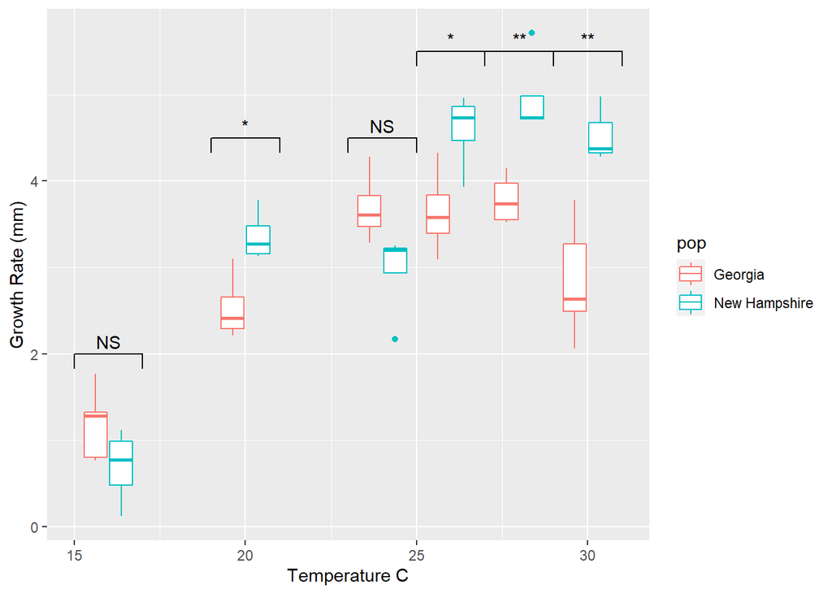

## New Hampshire-North Carolina

From our two-way ANOVA, we see that variance in growth rate is not signficantly different between populations across all temperatures.

Using post-hoc t-test between North Carolina and New Hampshire, we see that growth rate is different between populations at only one common garden temperature, 20 degrees.

```
##             Df Sum Sq Mean Sq F value   Pr(>F)
## pop          1   0.77    0.77   1.225    0.274
## temp         1  60.97   60.97  97.105 1.05e-12 ***
## pop:temp     1   1.69    1.69   2.693    0.108
## Residuals   44  27.63    0.63
## ---
## Signif. codes:  0 '***' 0.001 '**' 0.01 '*' 0.05 '.' 0.1 ' ' 1
```

```
##   temp    p-value
## 1   16 0.10845455
## 2   20 0.02147221
## 3   24 0.06580141
## 4   26 0.37987822
## 5   28 0.08140437
## 6   30 0.19376527
```

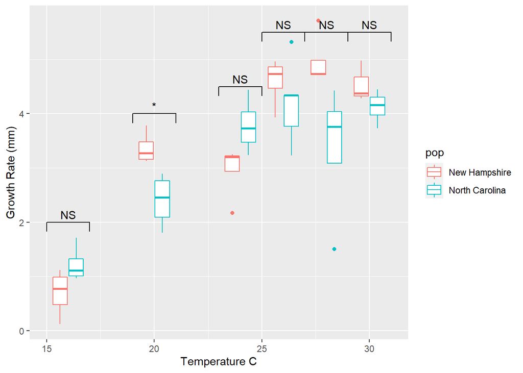

# North Carolina - Georgia Comparison

Using post-hoc t-tests between North Carolina and Georgia growth rates at each temperature, we see that while growth rates are not significantly different from one another at low temperatures, separation in growth rate is achieved at highest temperatures (28 and 30 C).

```
##             Df Sum Sq Mean Sq F value   Pr(>F)
## pop          1   4.95    4.95  10.288  0.00239 **
## temp         1  40.10   40.10  83.407 4.53e-12 ***
## pop:temp     1   1.72    1.72   3.571  0.06484 .
## Residuals   48  23.08    0.48
## ---
## Signif. codes:  0 '***' 0.001 '**' 0.01 '*' 0.05 '.' 0.1 ' ' 1
```

```
##   temp     p-value
## 1   16 0.708793670
## 2   20 0.752414088
## 3   24 0.904352579
## 4   26 0.351169496
## 5   28 0.004384037
## 6   30 0.013146493
```

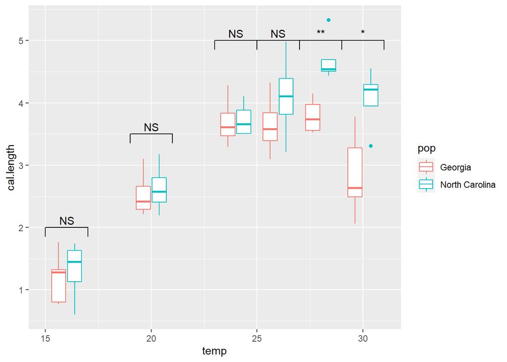

# Initial Hatchling Size comparison

One concern would be if initial starting size of hatchlings affected our growth results. We corrected for this by calculating growth rate (rather than final growth size), but it is still a factor to consider.

Here, we see through a one-way ANOVA that variance in initial hatchling size was significantly impacted by origin population.

```
##              Df Sum Sq Mean Sq F value   Pr(>F)
## pop           2  1.042  0.5211   11.64 2.03e-05 ***
## Residuals   147  6.581  0.0448
## ---
## Signif. codes:  0 '***' 0.001 '**' 0.01 '*' 0.05 '.' 0.1 ' ' 1
```

Using post-hoc Tukey pairwise comparisons, we see that initial hatchling size was significantly different between Georgia and New Hampshire, but not North Carolina and New Hampshire. This is interesting, as one might expect a larger initial size to give the Georgia population an enhanced final growth rate, but we see that is not the case in our analysis above.

```
##   Tukey multiple comparisons of means
##     95% family-wise confidence level
##
## Fit: aov(formula = cal.length.start ~ pop, data = cge)
##
## $pop
##                                     diff        lwr         upr     p adj
## New Hampshire-Georgia        -0.16304419 -0.2638682 -0.06222022 0.0005545
## North Carolina-Georgia       -0.18448265 -0.2832080 -0.08575731 0.0000554
## North Carolina-New Hampshire -0.02143846 -0.1227306  0.07985369 0.8708834
```

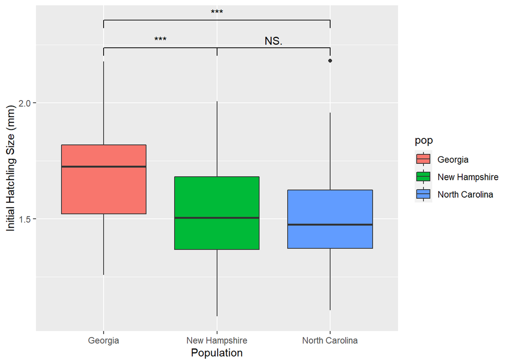